# Homework 1

Kadir Ahmet Aksu-IE360-Spring 2020

22 Nisan 2020

## Introduction

As we know,In recent years Turkish lira depreciated against dollar and euro.I downloaded some data that this loss of value might affect from EVDS.One of them is Cumhuriyet Gold Selling Price, because their price indexed to dollar.Also, I think Consumer Price Index is affected because Turkey imports esential goods and If dollar and euro increase, their price also increase.ALso, total credit given by banks may be affected by fluctuation in exchange rates because borrowing with dollar or euro is quite common.Also, Import and Export may be affected by fluctuation in exchange rates because euro or dollar is used in trade.

```r
library("zoo", lib.loc="~/R/win-library/3.6")
library("xts", lib.loc="~/R/win-library/3.6")
library("readxl", lib.loc="~/R/win-library/3.6")
```

```r
library("ggplot2", lib.loc="~/R/win-library/3.6")
library("data.table", lib.loc="~/R/win-library/3.6")
setwd('/Users/kadir/Desktop/')
data<-read_xlsx("dataexcel.xlsx")
```

Necessary packages are uploaded and the data is absorbed from Excel

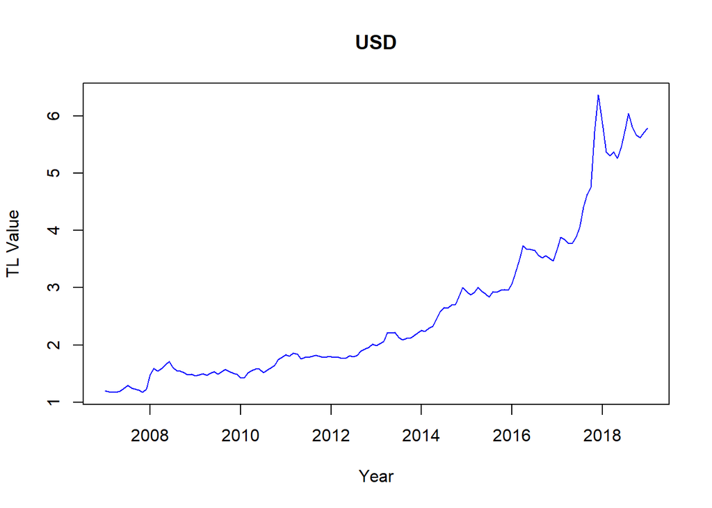

```r
Date<-xts(data, order.by = as.Date(as.yearmon(data$Date)))
Date <- subset( Date, select = -Date )
Date<-data.table(Date)
data <- subset( data, select = -Date )
USD<-data$USD
ts.USD<-ts(data =USD, start = 2007, end = 2019, frequency = 12,  deltat = 1)
ts.plot(ts.USD, col = 'blue', xlab = "Year", ylab = "TL Value",main="USD")
```

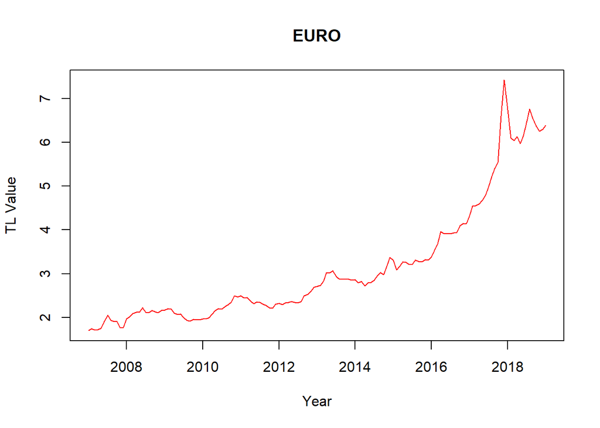

```r
EURO<-data$EURO
ts.EURO<-ts(data =EURO, start = 2007, end = 2019, frequency = 12,  deltat = 1)
ts.plot(ts.EURO, col = 'red', xlab = "Year", ylab = "TL Value", main="EURO")
```

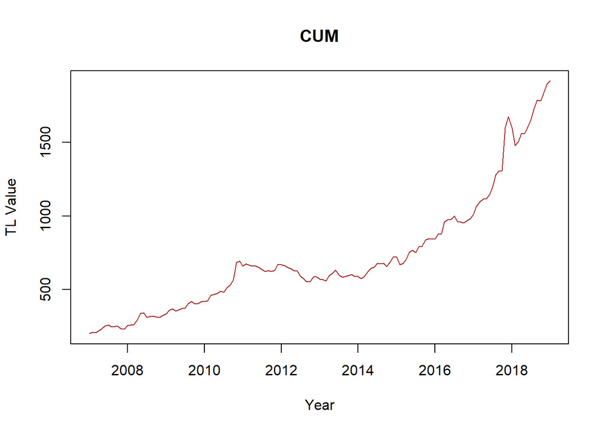

```r
CUM<-data$ `CUM TL`
ts.CUM<-ts(data =CUM, start = 2007, end = 2019, frequency = 12,  deltat = 1)
ts.plot(ts.CUM, col = 'brown', xlab = "Year", ylab = "TL Value", main="CUM")
```

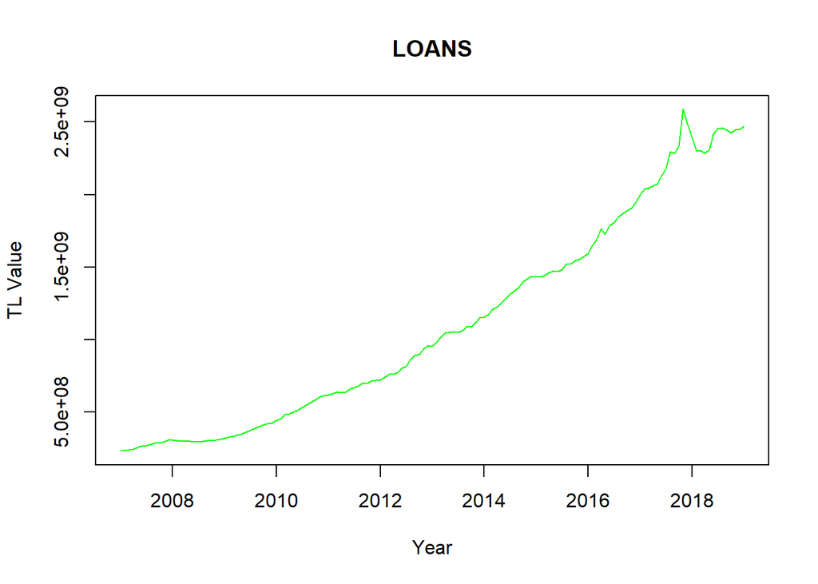

```r
LOANS<-data$ LOANS
ts.LOANS<-ts(data =LOANS, start = 2007, end = 2019, frequency = 12,  deltat = 1)
ts.plot(ts.LOANS, col = 'green', xlab = "Year", ylab = "TL Value" ,main="LOANS")
```

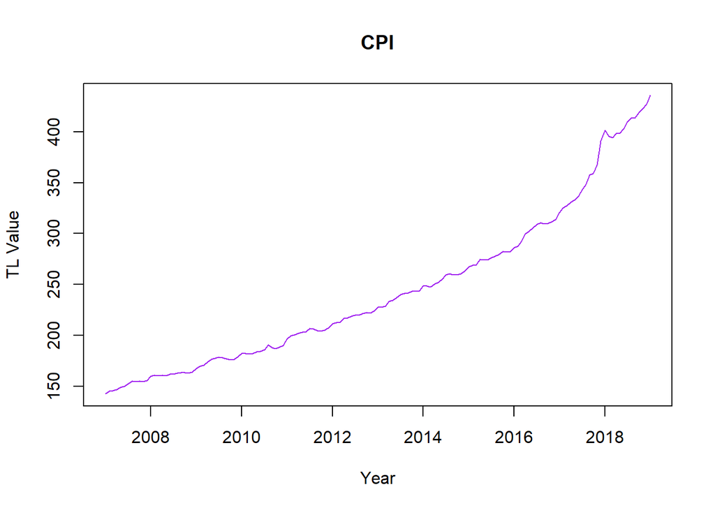

```r
CPI<-data$ CPI
ts.CPI<-ts(data =CPI, start = 2007, end = 2019, frequency = 12,  deltat = 1)
ts.plot(ts.CPI, col = 'purple', xlab = "Year", ylab = "TL Value" ,main="CPI")
```

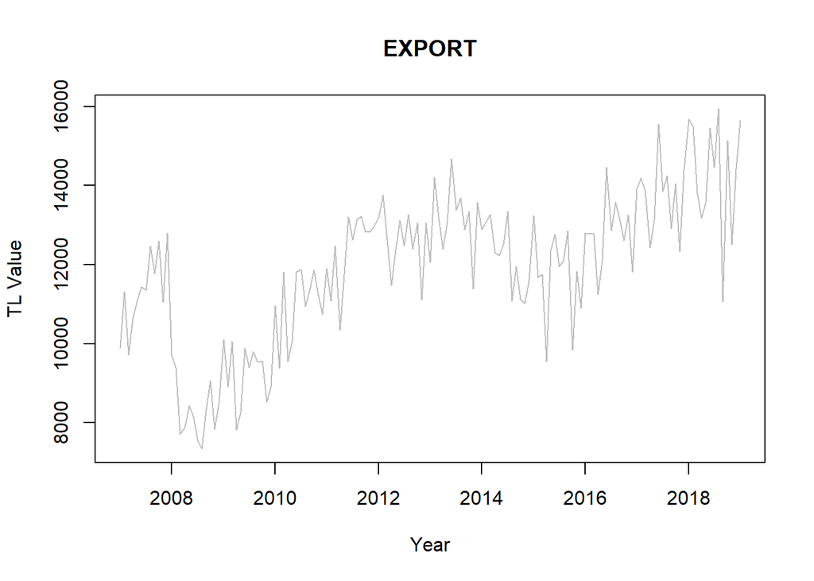

```r
EXPORT<-data$EXPORT
ts.EXPORT<-ts(data =EXPORT, start = 2007, end = 2019, frequency = 12,  deltat = 1)
ts.plot(ts.EXPORT, col = 'gray', xlab = "Year", ylab = "TL Value" ,main="EXPORT")
```

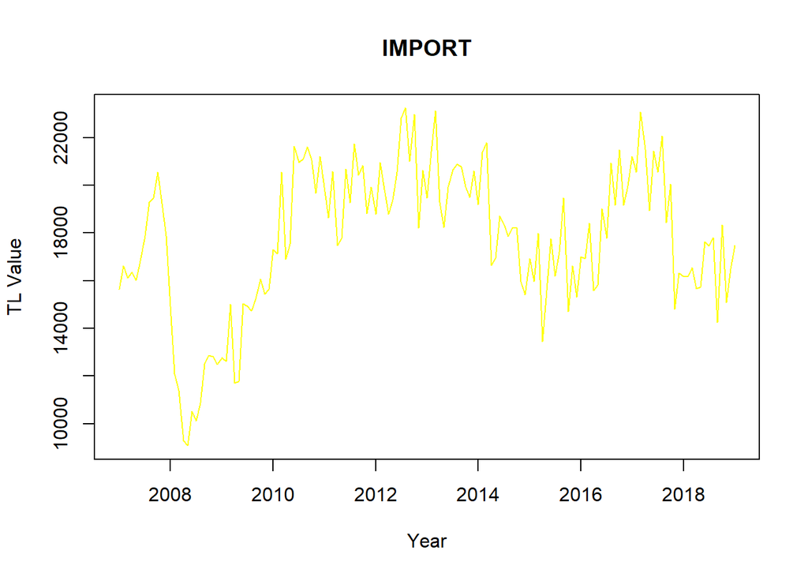

```r
IMPORT<-data$IMPORT
ts.IMPORT<-ts(data =IMPORT, start = 2007, end = 2019, frequency = 12,  deltat = 1)
ts.plot(ts.IMPORT, col = 'yellow', xlab = "Year", ylab = "TL Value",main="IMPORT")
```

All data sets are converted to time series and plotting to understand they are affected fluctuation in exchange rates or not

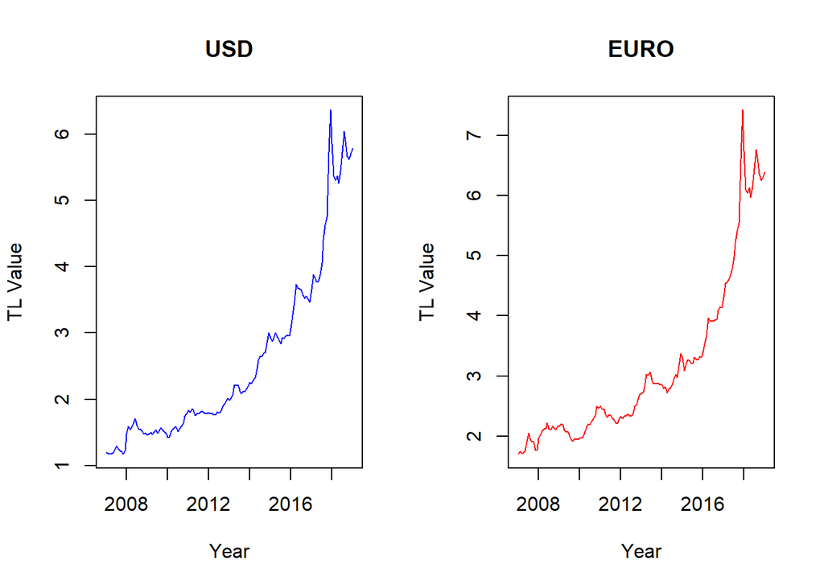

```r
par(mfrow=c(1,2))
ts.plot(ts.USD, col = 'blue', xlab = "Year", ylab = "TL Value",main="USD")
ts.plot(ts.EURO, col = 'red', xlab = "Year", ylab = "TL Value", main="EURO")
```

USD and Euro show similar changes

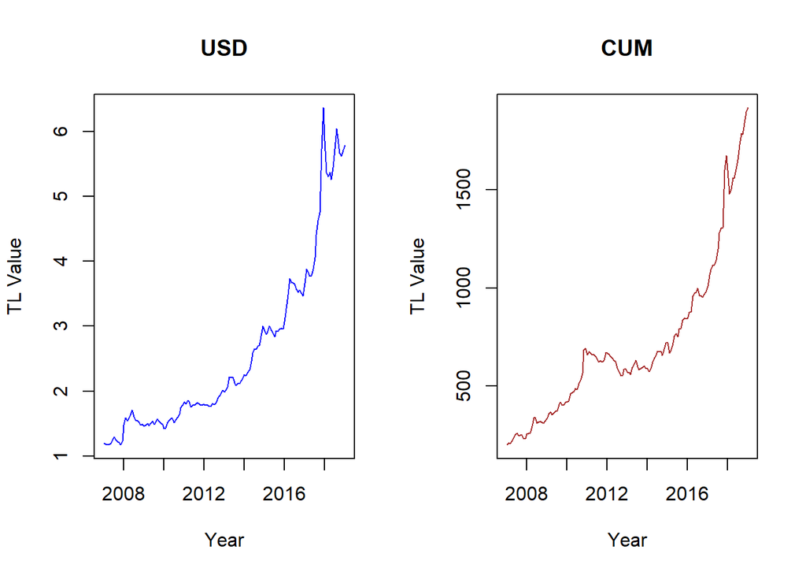

```r
par(mfrow=c(1,2))
ts.plot(ts.USD, col = 'blue', xlab = "Year", ylab = "TL Value",main="USD")
ts.plot(ts.CUM, col = 'brown', xlab = "Year", ylab = "TL Value", main="CUM")
```

USD and Cum show similar changes

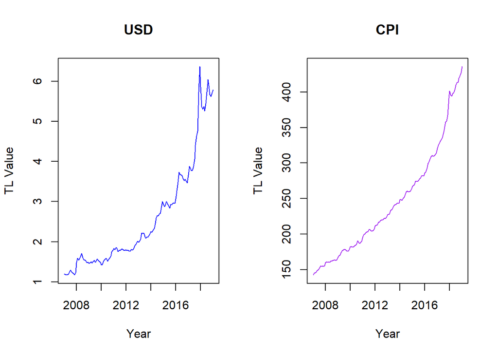

```r
par(mfrow=c(1,2))
ts.plot(ts.USD, col = 'blue', xlab = "Year", ylab = "TL Value",main="USD")
ts.plot(ts.CPI, col = 'purple', xlab = "Year", ylab = "TL Value" ,main="CPI")
```

USD and CPI show similar changes

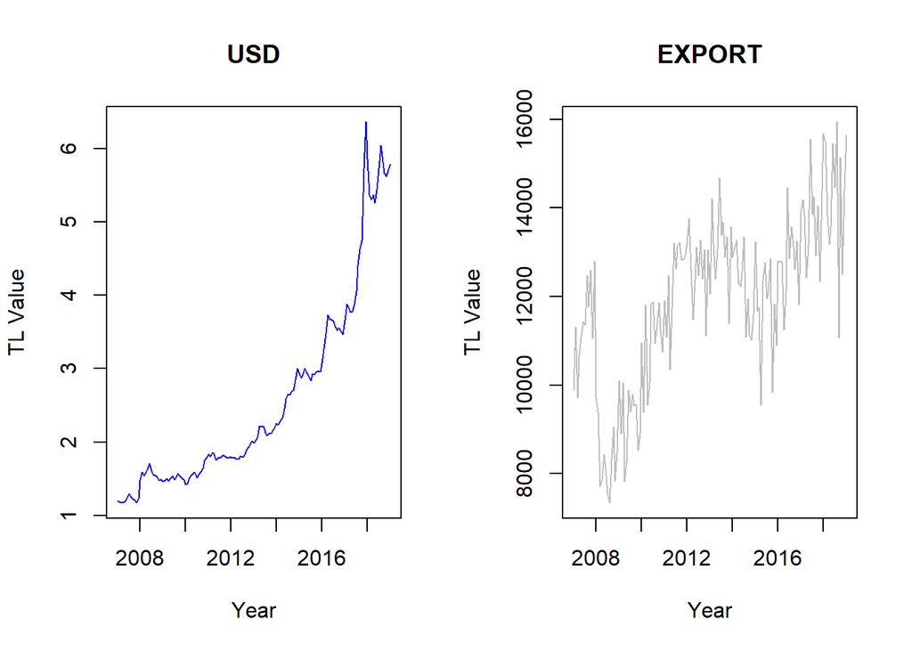

```r
par(mfrow=c(1,2))
ts.plot(ts.USD, col = 'blue', xlab = "Year", ylab = "TL Value",main="USD")
ts.plot(ts.EXPORT, col = 'gray', xlab = "Year", ylab = "TL Value" ,main="EXPORT")
```

USD and Export don’t show similar changes

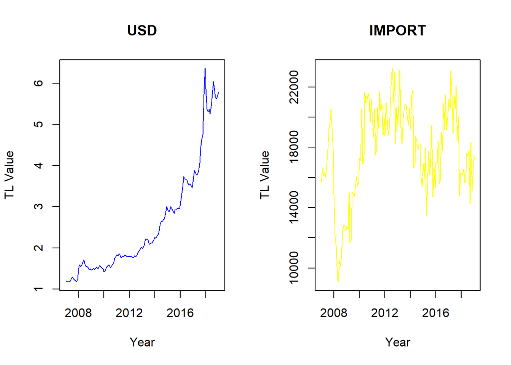

```r
par(mfrow=c(1,2))
ts.plot(ts.USD, col = 'blue', xlab = "Year", ylab = "TL Value",main="USD")
ts.plot(ts.IMPORT, col = 'yellow', xlab = "Year", ylab = "TL Value" ,main="IMPORT")
```

USD and Import don’t show similar changes

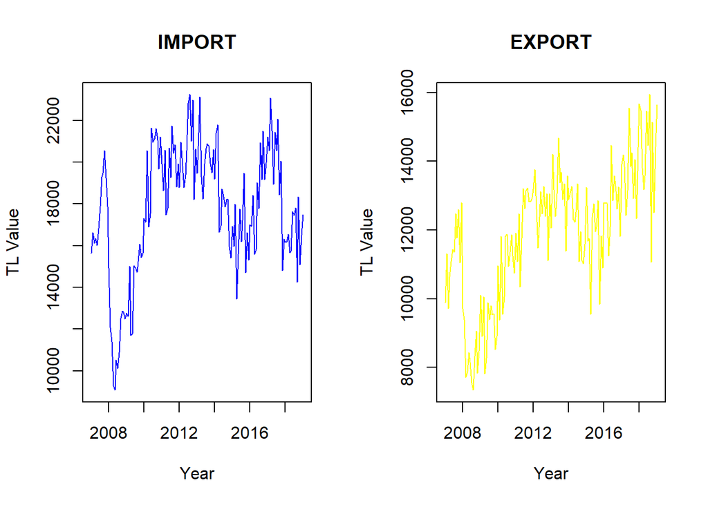

```r
par(mfrow=c(1,2))
ts.plot(ts.IMPORT, col = 'blue', xlab = "Year", ylab = "TL Value",main="IMPORT")
ts.plot(ts.EXPORT, col = 'yellow', xlab = "Year", ylab = "TL Value" ,main="EXPORT")
```

Import and export show similar changes

## Analysis

Fluctiation in exchange rates affects economics statistics.USD and Euro show similar changes. Both of them show similar changes witch CPI,Cumhuriyet gold price and Loan. But, they don’t show similar export and import. This doesn’t mean that exchange rates don’t affect import and export. However, other parameters affect exports and imports more than exchange rates.Import and export show similar changes but considering last years, When import decreasing, export doesn’t decrease.Because, Turkish lira depreciation makes import difficult.